# Peer-graded Assignment: Prediction Assignment Writeup

Yu Gan

January 9, 2018

## Background

Using devices such as Jawbone Up, Nike FuelBand, and Fitbit it is now possible to collect a large amount of data about personal activity relatively inexpensively. These type of devices are part of the quantified self movement - a group of enthusiasts who take measurements about themselves regularly to improve their health, to find patterns in their behavior, or because they are tech geeks. One thing that people regularly do is quantify how much of a particular activity they do, but they rarely quantify how well they do it. In this project, your goal will be to use data from accelerometers on the belt, forearm, arm, and dumbell of 6 participants. They were asked to perform barbell lifts correctly and incorrectly in 5 different ways. More information is available from the website here: http://web.archive.org/web/20161224072740/http:/groupware.les.inf.puc-rio.br/har (see the section on the Weight Lifting Exercise Dataset).

## Data loading and processing

```r
setwd("D:/Downloads/R")
url_train="https://d396qusza40orc.cloudfront.net/predmachlearn/pml-training.csv"
url_test="https://d396qusza40orc.cloudfront.net/predmachlearn/pml-testing.csv"
download.file(url_train,destfile="training_data.csv")
download.file(url_test,destfile="testing_data.csv")
library(readr)
training<-read.csv("D:/Downloads/R/training_data.csv",na.strings = c("NA", "#DIV/0!", ""))
testing <- read.csv("D:/Downloads/R/testing_data.csv",na.strings = c("NA", "#DIV/0!", ""))
```

### Removing columns that contains NA values and irrelevant variables

```r
training <- training[, which(colSums(is.na(training)) == 0)]
testing <- testing[, which(colSums(is.na(testing)) == 0)]
training <- training[,-c(1:7)] ##the first 7 columns are variables that has no relationship with "class"
testing <- testing[,-c(1:7)]
```

### Partioning the training set into training and crossvalidation datasets

```r
library(caret)
set.seed(888)
training = data.frame(training)
inTrain <- createDataPartition(training$classe, p=0.70, list=F)
train <- training[inTrain, ]
validation <- training[-inTrain, ]
```

## Building model and cross validation

### Modelling with regression tree (“rpart”)

```r
fit1 <- train(classe ~ ., method="rpart", data=train)
val1 <- predict(fit1, validation)
confusionMatrix(validation$classe, val1)
```

```
## Confusion Matrix and Statistics
##
##           Reference
## Prediction    A    B    C    D    E
##          A 1530   21  120    0    3
##          B  456  425  258    0    0
##          C  452   36  538    0    0
##          D  429  165  370    0    0
##          E  154  150  291    0  487
##
## Overall Statistics
##
##                Accuracy : 0.5064
##                  95% CI : (0.4935, 0.5192)
##     No Information Rate : 0.5133
##     P-Value [Acc > NIR] : 0.8604
##
##                   Kappa : 0.3554
##  Mcnemar's Test P-Value : NA
##
## Statistics by Class:
##
##                      Class: A Class: B Class: C Class: D Class: E
## Sensitivity            0.5065  0.53325  0.34115       NA  0.99388
## Specificity            0.9497  0.85967  0.88672   0.8362  0.88971
## Pos Pred Value         0.9140  0.37313  0.52437       NA  0.45009
## Neg Pred Value         0.6459  0.92162  0.78617       NA  0.99938
## Prevalence             0.5133  0.13543  0.26797   0.0000  0.08326
## Detection Rate         0.2600  0.07222  0.09142   0.0000  0.08275
## Detection Prevalence   0.2845  0.19354  0.17434   0.1638  0.18386
## Balanced Accuracy      0.7281  0.69646  0.61394       NA  0.94180
```

### Modelling with random forest (“rf”)

```r
fit2 <- train(classe ~ ., method="rf", data=train, prox=TRUE,ntree=250)
val2 <- predict(fit2, validation)
confusionMatrix(validation$classe, val2)
```

```
## Confusion Matrix and Statistics
##
##           Reference
## Prediction    A    B    C    D    E
##          A 1674    0    0    0    0
##          B   14 1121    4    0    0
##          C    0    3 1020    3    0
##          D    0    0   11  953    0
##          E    0    0    1    3 1078
##
## Overall Statistics
##
##                Accuracy : 0.9934
##                  95% CI : (0.991, 0.9953)
##     No Information Rate : 0.2868
##     P-Value [Acc > NIR] : < 2.2e-16
##
##                   Kappa : 0.9916
##  Mcnemar's Test P-Value : NA
##
## Statistics by Class:
##
##                      Class: A Class: B Class: C Class: D Class: E
## Sensitivity            0.9917   0.9973   0.9846   0.9937   1.0000
## Specificity            1.0000   0.9962   0.9988   0.9978   0.9992
## Pos Pred Value         1.0000   0.9842   0.9942   0.9886   0.9963
## Neg Pred Value         0.9967   0.9994   0.9967   0.9988   1.0000
## Prevalence             0.2868   0.1910   0.1760   0.1630   0.1832
## Detection Rate         0.2845   0.1905   0.1733   0.1619   0.1832
## Detection Prevalence   0.2845   0.1935   0.1743   0.1638   0.1839
## Balanced Accuracy      0.9959   0.9968   0.9917   0.9958   0.9996
```

### Modelling with boosted trees (“gbm”)

```r
fit3 <- train(classe ~ ., method="gbm", data=train,trControl=trainControl(method = "repeatedcv", number = 5, repeats = 1),verbose=FALSE)
val3 <- predict(fit3, validation)
confusionMatrix(validation$classe, val3)
```

```
## Confusion Matrix and Statistics
##
##           Reference
## Prediction    A    B    C    D    E
##          A 1643   22    7    2    0
##          B   45 1070   24    0    0
##          C    0   33  981   11    1
##          D    2    2   34  915   11
##          E    1   10    4   13 1054
##
## Overall Statistics
##
##                Accuracy : 0.9623
##                  95% CI : (0.9571, 0.967)
##     No Information Rate : 0.2873
##     P-Value [Acc > NIR] : < 2.2e-16
##
##                   Kappa : 0.9523
##  Mcnemar's Test P-Value : 4.894e-06
##
## Statistics by Class:
##
##                      Class: A Class: B Class: C Class: D Class: E
## Sensitivity            0.9716   0.9411   0.9343   0.9724   0.9887
## Specificity            0.9926   0.9855   0.9907   0.9901   0.9942
## Pos Pred Value         0.9815   0.9394   0.9561   0.9492   0.9741
## Neg Pred Value         0.9886   0.9859   0.9858   0.9947   0.9975
## Prevalence             0.2873   0.1932   0.1784   0.1599   0.1811
## Detection Rate         0.2792   0.1818   0.1667   0.1555   0.1791
## Detection Prevalence   0.2845   0.1935   0.1743   0.1638   0.1839
## Balanced Accuracy      0.9821   0.9633   0.9625   0.9812   0.9915
```

The above result show that the random forest model has the highest accuracy in cross validation. Therefore, we will use the random forest model for predicting test samples.

## Prediction

We used the random forest model for prediction

```r
pred <- predict(fit2, newdata=testing)
pred
```

```
##  [1] B A B A A E D B A A B C B A E E A B B B
## Levels: A B C D E
```

## Appendix

### Plotting decision tree(method=“rpart”)

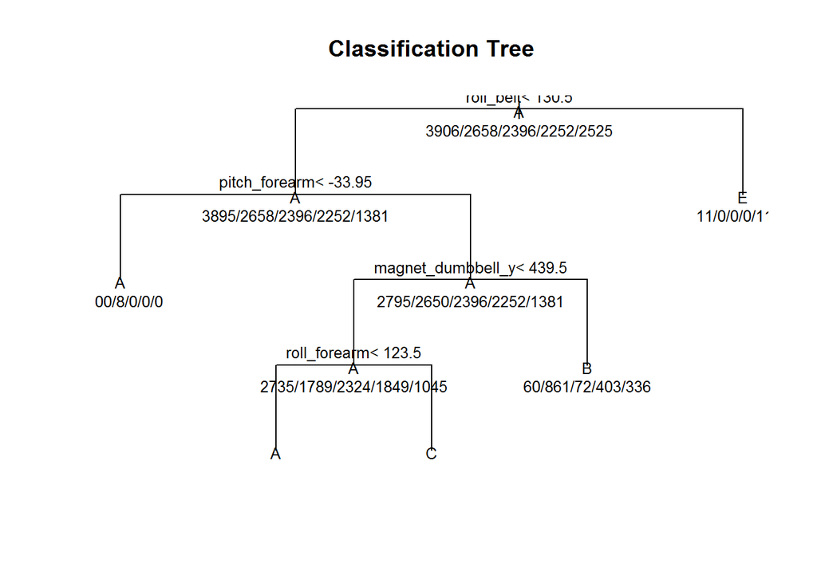